# Explanatory Data Analysis on HR Data

## Preparation

We start by loading required libraries for this study.

```r
library(tidyverse)
library(ggplot2)
library(ggcorrplot)
library(ggthemes)
library(formattable)
library(htmlwidgets)
library(ggalt)
library(party)
library(rpart)
library(rpart.plot)
library(pROC)
```

## Abstract

The dataset we have choosen is about human resources. Our aim is to answer an interesting question of a company such as “*Why are our best and most experienced employees leaving prematurely?*” We will try to find an answer to this question by analyzing answers of the employees to the job satisfaction survey and their work related records. The dataset is formed by the Human Resources (HR) department after conducting a survey on their employees. In this study we first run an *Explanatory Data Analysis (EDA)* on tha data to make it more meaningfull, then we applied *Principal Component Analysis (PCA)* to understand the factors that cause employess to leave. With the help of *k-Means clustering* we obtained three different groups of employees that left with similar reasons and then employed a decision three analysis to predict the employees that will possibly leave the company in the future.

## Data Description

All the data collected is from last 5 years whereas accident data belongs to past 2 years. This HR database does not take into account the employees that have been fired, transferred or hired in the past year. Our objective is to make predictions about the probabilities that employees may leave their company and what to change to increase their satisfaction levels. We will try to give insights to make best employees more loyal.

## Our tentative plan is as follows:

1. Explore the dimensions of variables
2. Clean the data if required
3. Summarise the data and search for correlations wherever possible
4. Visualize the filtered results
5. Make conclusions and give insights

## Explanatory Data Analysis

### Loading the Data

Then we read dataset from csv file and had a quick look at its form.

```r
d=read.csv("HR_comma_sep.csv")
d<- d %>% rename("departments" = "sales") %>% tbl_df()
glimpse(d)
```

```
## Observations: 14,999
## Variables: 10
## $ satisfaction_level    <dbl> 0.38, 0.80, 0.11, 0.72, 0.37, 0.41, 0.10...
## $ last_evaluation       <dbl> 0.53, 0.86, 0.88, 0.87, 0.52, 0.50, 0.77...
## $ number_project        <int> 2, 5, 7, 5, 2, 2, 6, 5, 5, 2, 2, 6, 4, 2...
## $ average_montly_hours  <int> 157, 262, 272, 223, 159, 153, 247, 259, ...
## $ time_spend_company    <int> 3, 6, 4, 5, 3, 3, 4, 5, 5, 3, 3, 4, 5, 3...
## $ Work_accident         <int> 0, 0, 0, 0, 0, 0, 0, 0, 0, 0, 0, 0, 0, 0...
## $ left                  <int> 1, 1, 1, 1, 1, 1, 1, 1, 1, 1, 1, 1, 1, 1...
## $ promotion_last_5years <int> 0, 0, 0, 0, 0, 0, 0, 0, 0, 0, 0, 0, 0, 0...
## $ departments           <fctr> sales, sales, sales, sales, sales, sale...
## $ salary                <fctr> low, medium, medium, low, low, low, low...
```

As you can see we have 14999 observations for job satisfaction level, latest evaluation (yearly), number of projects worked on, average monthly hours, time spend in the company (in years), work accident (within the past 2 years), promotion within the past 5 years, department and salary. All of them are numeric values except last two columns.

We also checked whether there is any NA or NaN values.

```r
which(is.na.data.frame(d))
```

```
## integer(0)
```

Since there aren’t any NA/NaN values, no need to omit or complete them. Thus we proceed summarizing the data.

```r
summary(d)
```

```
##  satisfaction_level last_evaluation  number_project  average_montly_hours
##  Min.   :0.0900     Min.   :0.3600   Min.   :2.000   Min.   : 96.0
##  1st Qu.:0.4400     1st Qu.:0.5600   1st Qu.:3.000   1st Qu.:156.0
##  Median :0.6400     Median :0.7200   Median :4.000   Median :200.0
##  Mean   :0.6128     Mean   :0.7161   Mean   :3.803   Mean   :201.1
##  3rd Qu.:0.8200     3rd Qu.:0.8700   3rd Qu.:5.000   3rd Qu.:245.0
##  Max.   :1.0000     Max.   :1.0000   Max.   :7.000   Max.   :310.0
##
##  time_spend_company Work_accident         left
##  Min.   : 2.000     Min.   :0.0000   Min.   :0.0000
##  1st Qu.: 3.000     1st Qu.:0.0000   1st Qu.:0.0000
##  Median : 3.000     Median :0.0000   Median :0.0000
##  Mean   : 3.498     Mean   :0.1446   Mean   :0.2381
##  3rd Qu.: 4.000     3rd Qu.:0.0000   3rd Qu.:0.0000
##  Max.   :10.000     Max.   :1.0000   Max.   :1.0000
##
##  promotion_last_5years      departments      salary
##  Min.   :0.00000       sales      :4140   high  :1237
##  1st Qu.:0.00000       technical  :2720   low   :7316
##  Median :0.00000       support    :2229   medium:6446
##  Mean   :0.02127       IT         :1227
##  3rd Qu.:0.00000       product_mng: 902
##  Max.   :1.00000       marketing  : 858
##                        (Other)    :2923
```

Here the employee’s salary ranges can be seen in more detail:

```r
d %>%
  count(salary) %>%
  formattable(align = 'l')
```

| salary | n |
| --- | --- |
| high | 1237 |
| low | 7316 |
| medium | 6446 |

We can see clearly that the range of salaries are not well balanced. Only 8% of the employees are paid highly, while 48% of them are in the low salary range.

Departmentwise employee count is as follows:

```r
d %>%
  count(departments) %>%
  formattable(align = 'l')
```

| departments | n |
| --- | --- |
| accounting | 767 |
| hr | 739 |
| IT | 1227 |
| management | 630 |
| marketing | 858 |
| product_mng | 902 |
| RandD | 787 |
| sales | 4140 |
| support | 2229 |
| technical | 2720 |

As you can see *Sales Department* is the largest and *Management* is the smallest in size.

Departmentwise salary frequencies are shown below:

```r
d %>%
  count(departments, salary) %>% group_by(departments) %>%
  mutate(
    salary = ordered(salary, c("low", "medium", "high")),
    n = percent(n, 0),
    n = n/sum(n)
  ) %>%
  spread(salary, n) %>%
  formattable(list(area(T, 2:4) ~ color_tile("grey", "pink")), align = 'l')
```

| departments | low | medium | high |
| --- | --- | --- | --- |
| accounting | 0.46675359 | 0.43676662 | 0.09647979 |
| hr | 0.45331529 | 0.48579161 | 0.06089310 |
| IT | 0.49633252 | 0.43602282 | 0.06764466 |
| management | 0.28571429 | 0.35714286 | 0.35714286 |
| marketing | 0.46853147 | 0.43822844 | 0.09324009 |
| product_mng | 0.50000000 | 0.42461197 | 0.07538803 |
| RandD | 0.46251588 | 0.47268107 | 0.06480305 |
| sales | 0.50700483 | 0.42801932 | 0.06497585 |
| support | 0.51413190 | 0.42261104 | 0.06325707 |
| technical | 0.50441176 | 0.42169118 | 0.07389706 |

As it is better visualised in the table above, only *Management Department* is well balanced in terms of salary. Other than that the rest of the departments are paid in the lower and medium wage nearly equally. Since nearly all of the employess work for low and medium wage, salary alone cannot be a dominant factor for the decision of quiting.

Now, having known all the column names and their related statistics, we wanted to visualize the distribution of the numerical ones, just to get better understanding for further interpretations. For this reason we employed histogram plots. Notice that bin sizes are adapted with respect to varying ranges of the data.

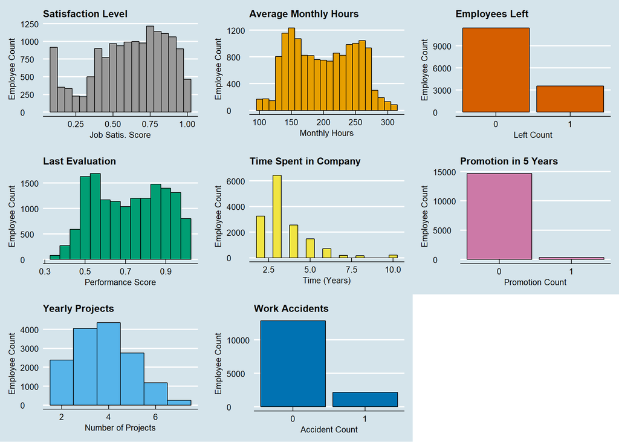

```r
p1 <- ggplot(subset(d ), aes(x=satisfaction_level, colour=satisfaction_level)) +
  theme_economist() +
  scale_color_economist()+
  theme(plot.title = element_text(size=12)) +
  geom_histogram(binwidth = 0.05,color = 'black', fill = '#999999')  +
  ggtitle("Satisfaction Level") +
  labs(x="Job Satis. Score", y="Employee Count", size = 8)



p2 <- ggplot(subset(d ), aes(x=last_evaluation, colour=last_evaluation)) +
  theme_economist() +
  scale_color_economist()+
  theme(plot.title = element_text(size=12)) +
  geom_histogram(binwidth = 0.05,color = 'black', fill = '#009E73') +
  ggtitle("Last Evaluation") +
  labs(x="Performance Score", y="Employee Count", size = 8)

p3 <- ggplot(subset(d ), aes(x=number_project, colour=number_project)) +
  theme_economist() +
  scale_color_economist()+
  theme(plot.title = element_text(size=12)) +
  geom_histogram(binwidth = 1,color = 'black', fill = '#56B4E9')  +
  ggtitle("Yearly Projects") +
  labs(x="Number of Projects", y="Employee Count", size = 8)

p4 <- ggplot(subset(d ), aes(x=average_montly_hours, colour=average_montly_hours)) +
  theme_economist() +
  scale_color_economist()+
  theme(plot.title = element_text(size=12)) +
  geom_histogram(binwidth = 10,color = 'black', fill = '#E69F00')  +
  ggtitle("Average Monthly Hours")+
  labs(x="Monthly Hours", y="Employee Count", size = 8)


p5 <- ggplot(subset(d ), aes(x=time_spend_company, colour=time_spend_company)) +
  theme_economist() +
  scale_color_economist()+
  theme(plot.title = element_text(size=12)) +
  geom_histogram(binwidth = 0.5,color = 'black', fill = '#F0E442')  +
  ggtitle("Time Spent in Company") +
  labs(x="Time (Years)", y="Employee Count", size = 8)

p6 <- ggplot(subset(d ), aes(x=Work_accident, colour=Work_accident)) +
  theme_economist() +
  scale_color_economist()+
  theme(plot.title = element_text(size=12)) +
  geom_bar(color = 'black', fill = '#0072B2')+ ## +
  ggtitle("Work Accidents") +
  labs(x="Accident Count", y="Employee Count", size = 8) +
  scale_x_continuous(breaks = c(0,1,1))

p7 <- ggplot(subset(d ), aes(x=left, colour=left)) +
  theme_economist() +
  scale_color_economist()+
  theme(plot.title = element_text(size=12)) +
  geom_bar(color = 'black', fill = '#D55E00') +
  ggtitle("Employees Left") +
  labs(x="Left Count", y="Employee Count", size = 8) +
  scale_x_continuous(breaks = c(0,1,1))


p8 <- ggplot(subset(d), aes(x=promotion_last_5years, colour=promotion_last_5years)) +
  theme_economist() +
  scale_color_economist()+
  theme(plot.title = element_text(size=12)) +
  scale_x_continuous(breaks = c(0,1,1)) +
  geom_bar(color = 'black', fill = '#CC79A7') +
  ggtitle("Promotion in 5 Years") +
  labs(x="Promotion Count", y="Employee Count", size = 8)


multiplot(p1,p2,p3,p4,p5,p6,p7,p8,cols=3)
```

According to above histograms, we found that; there was nearly no promoted employee in the last five years. Bear in mind that the work accident data belongs to last two years and frequency of accidents is low but not zero. Monthly time spent in the company and number of projects which each employee works on both have positively skewed distributions. So, instead of mean, median value must be considered. Thus, a common employee works 4 projects per year, spending 200 hours per month. Average monthly hours and last evauation score histograms are bimodal. There are two main group of workers in this company: one works for short (~150 h) on works for very long (~260 h) with medium (~0.55) and high evaluation scores (~0.85).

Let’s have a look at departmentwise job satisfaction level of the employees.

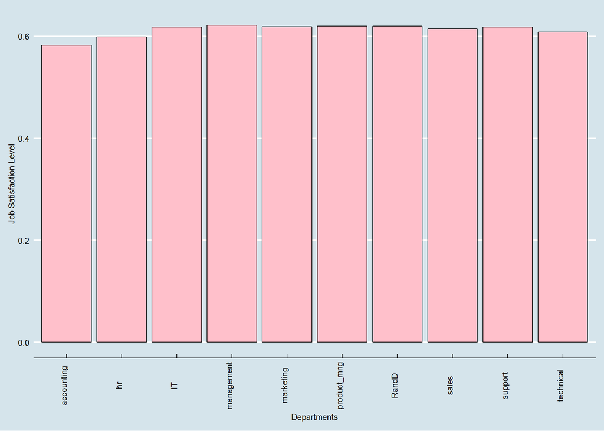

```r
  dep_satis <- d %>%
  group_by(departments) %>%
  summarise (Satisfaction =mean(satisfaction_level))
  ggplot(data=dep_satis, aes(x=departments, y=Satisfaction)) +
  theme_economist() +
  scale_color_economist()+
  theme(axis.text.x = element_text(angle = 90, hjust=0.5),axis.text = element_text(size=10) )+
  geom_bar(stat="identity", position=position_dodge(), fill="pink", colour="black")+
  labs(x= "Departments", y="Job Satisfaction Level")
```

It appears that the level of satisfaction is pretty much the same for all the departments except for some unhappy folks in the accounting department. While rest of the departments average satisfaction value is around 60% (which complies with overall satisfaction rate of 61.28%), accounting department’s mean is below the company’s mean.

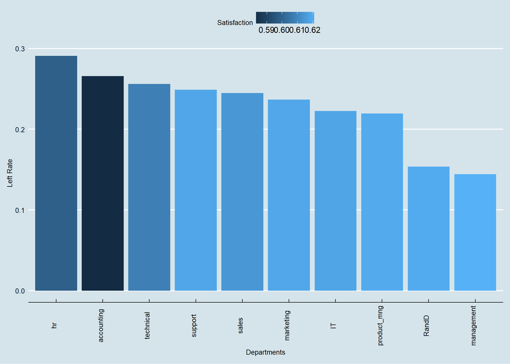

```r
depLeftSatis <- d %>% group_by(departments) %>% summarise(Total =n(),LeftCount = sum(left), Satisfaction = mean(satisfaction_level) ) %>% mutate(LeftRate = LeftCount/Total)



ggplot(data = depLeftSatis, aes( x = reorder(departments, -LeftRate), y = LeftRate, fill = Satisfaction)) +
    theme_economist() +
    scale_color_economist()+
    theme(axis.text.x = element_text(angle = 90, hjust=0.5))+
    geom_col()+labs(x= "Departments", y="Left Rate")
```

Among all the departments, *HR* is the one with highest attrition rate, then follows *Accounting*. The top three departments are also the most unsatisfied ones in which *Accounting* peaks in unhappiness. From the graph above we deduced that *Satisfaction Level* is a pretty important factor in quitting the company.

We also replotted the graph above by filling each bar according to the salary distribution of the department of interest. The salary imbalance within the departments as well as the whole company is apperent again.

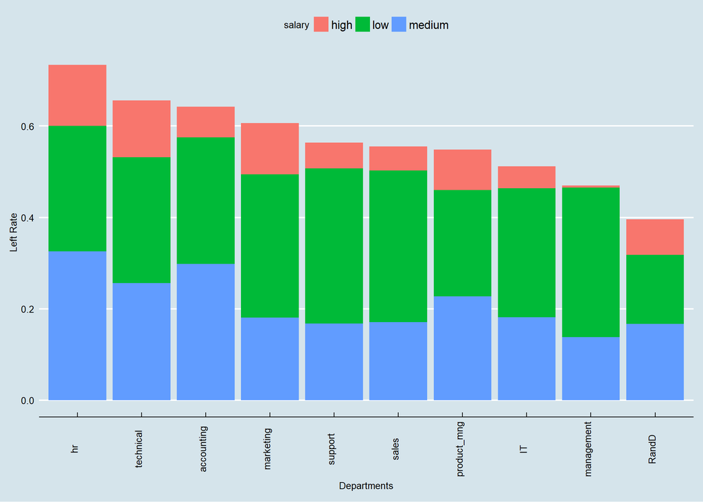

```r
depLeftSatis <- d %>% group_by(departments,salary) %>% summarise(Total =n(),LeftCount = sum(left), Satisfaction = mean(satisfaction_level) ) %>% mutate(LeftRate = LeftCount/Total)

ggplot(data = depLeftSatis, aes( x = reorder(departments, -LeftRate), y = LeftRate, fill=salary)) +
    theme_economist() +
    scale_color_economist()+
    theme(axis.text.x = element_text(angle = 90, hjust=0.5)) +
    geom_bar(stat="identity",position = "stack")+labs(x= "Departments", y="Left Rate")
```

Notice that altough job satisfaction level is uniformly distributed among the departments, the left rate is not, it is maximized at the HR department. So there must be other factors that effect employee’s decision to sign-out, such as long working hours.

Now, let’s look at the categorical variables; salary and departments. We wanted to compare the resigned and the remained employees by departments and salary categories. Bear in mind that in the graphs below the left ratio is not plotted but total count is. The departments with the highest left ratio are *HR*, *Accounting* and *Technical* departments. We already noticed that salary category did not give much insight about the characteristics of people left. However, if one is paid high in this company he/she is unlikely to resing.

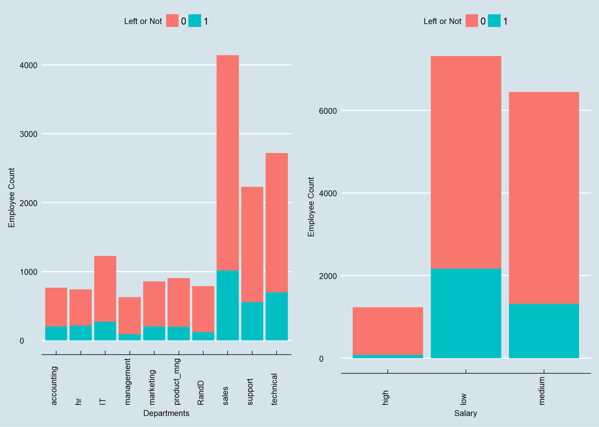

```r
p9 <- ggplot(d, aes(x=d$departments,fill=as.character(d$left)))+
      theme_economist() +
      scale_color_economist()+
      theme(axis.text.x = element_text(angle = 90, hjust=0))+
      geom_bar() +
      labs(x="Departments", y="Employee Count", fill="Left or Not")

p10 <- ggplot(d, aes(x=d$salary,fill=as.character(d$left) ))+
       theme_economist() +
       scale_color_economist()+
       theme(axis.text.x = element_text(angle = 90, hjust=0))+
       geom_bar() +
       labs(x="Salary", y ="Employee Count",fill="Left or Not")

multiplot(p9,p10,cols=2)
```

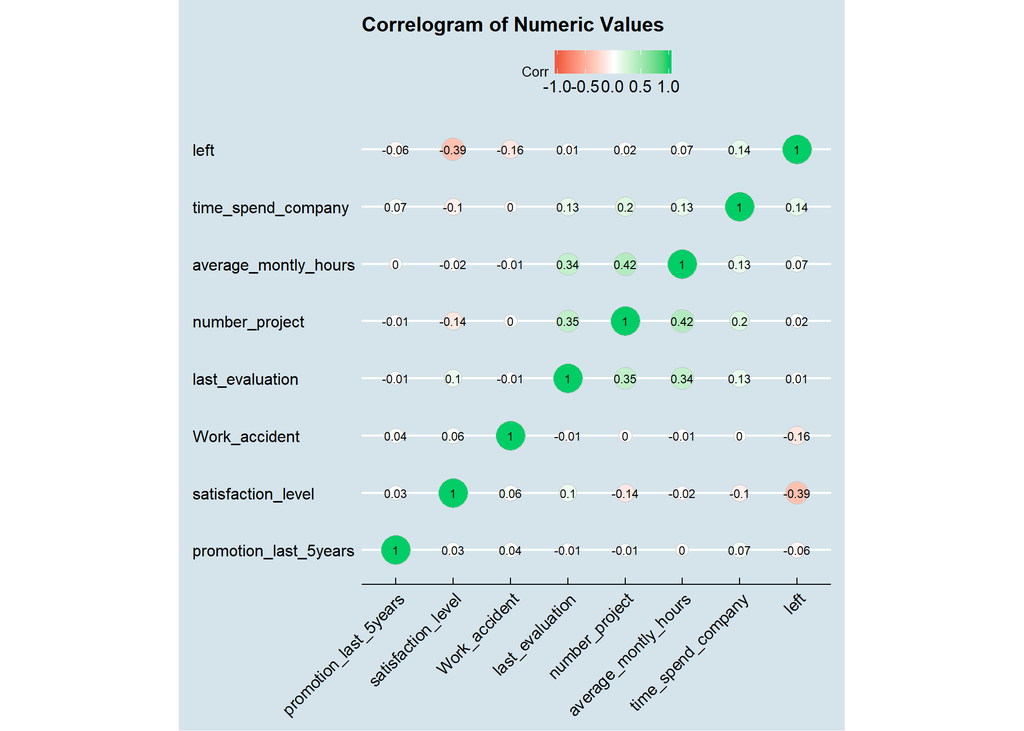

```r
CorrMat <- round(cor(d[,0:8]),3)
ggcorrplot(CorrMat, hc.order = TRUE,
           #type = "lower",
           lab = TRUE,
           lab_size = 3,
           method="circle",
           colors = c("tomato2", "white", "springgreen3"),
           title="Correlogram of Numeric Values",
           ggtheme=theme_economist)
```

Maybe it is better to focus on the people who quit, already. For this reason we filtered our data.

```r
dLeft <- d %>% filter(left==1) %>% select(-left)
summary(dLeft)
```

```
##  satisfaction_level last_evaluation  number_project  average_montly_hours
##  Min.   :0.0900     Min.   :0.4500   Min.   :2.000   Min.   :126.0
##  1st Qu.:0.1300     1st Qu.:0.5200   1st Qu.:2.000   1st Qu.:146.0
##  Median :0.4100     Median :0.7900   Median :4.000   Median :224.0
##  Mean   :0.4401     Mean   :0.7181   Mean   :3.856   Mean   :207.4
##  3rd Qu.:0.7300     3rd Qu.:0.9000   3rd Qu.:6.000   3rd Qu.:262.0
##  Max.   :0.9200     Max.   :1.0000   Max.   :7.000   Max.   :310.0
##
##  time_spend_company Work_accident     promotion_last_5years
##  Min.   :2.000      Min.   :0.00000   Min.   :0.000000
##  1st Qu.:3.000      1st Qu.:0.00000   1st Qu.:0.000000
##  Median :4.000      Median :0.00000   Median :0.000000
##  Mean   :3.877      Mean   :0.04733   Mean   :0.005321
##  3rd Qu.:5.000      3rd Qu.:0.00000   3rd Qu.:0.000000
##  Max.   :6.000      Max.   :1.00000   Max.   :1.000000
##
##      departments      salary
##  sales     :1014   high  :  82
##  technical : 697   low   :2172
##  support   : 555   medium:1317
##  IT        : 273
##  hr        : 215
##  accounting: 204
##  (Other)   : 613
```

We pairwise plotted job satisfaction level versus average montly hours and also satisfaction level versus time spent in the company. Meanwhile, we also highlighted employees left the company.

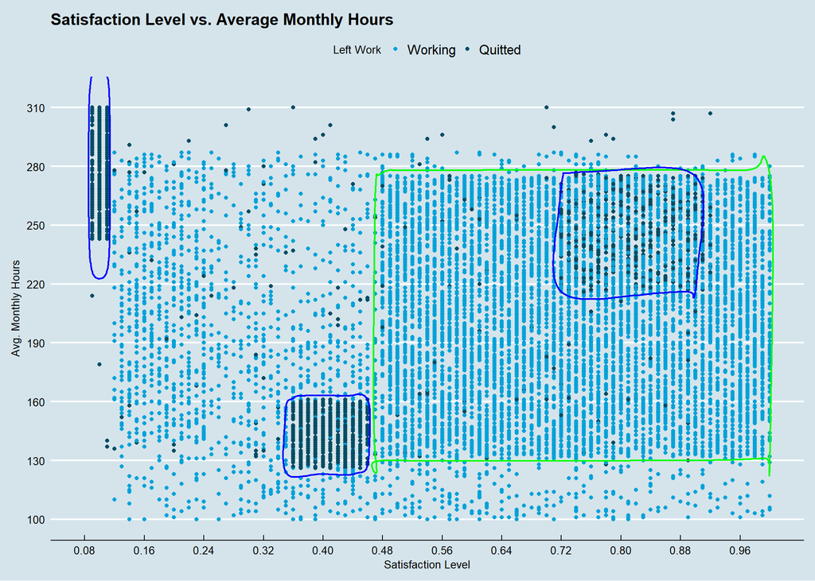

```r
#Define three main groups which left the company
d$left <- factor(d$left, labels=c("Working", "Quitted"))

gg <- ggplot(d,aes(satisfaction_level,average_montly_hours)) +   theme_economist() + scale_color_economist()

gg <- gg +geom_point(aes(col=factor(d$left)))

gg + geom_encircle(data=subset(d,
                               satisfaction_level>=0.05 &
                                 satisfaction_level<0.12 &
                                 average_montly_hours>240 &
                                 average_montly_hours<=310), colour="blue",expand=0.05,spread=0.02,size=2) +
  geom_encircle(data=subset(d,
                               satisfaction_level>=0.35 &
                                 satisfaction_level<0.47 &
                                 average_montly_hours>122 &
                                 average_montly_hours<164), colour="blue", expand=0,spread=0.02,size=2) +
  geom_encircle(data=subset(d,
                               satisfaction_level>=0.47 &
                                 satisfaction_level<=1 &
                                 average_montly_hours>129 &
                                 average_montly_hours<279), colour="green", expand=0, spread=0.02,size=2) +
  geom_encircle(data=subset(d,
                               satisfaction_level>=0.715 &
                                 satisfaction_level<=0.9 &
                                 average_montly_hours>215 &
                                 average_montly_hours<278), colour="blue", expand=0, spread=0.02,size=2) +

  scale_x_continuous(breaks=seq(0.08, 1, 0.08), limits = c(0.08, 1)) +
  scale_y_continuous(breaks=seq(100, 315, 30), limits = c(100, 315)) +
  labs(x="Satisfaction Level",y="Avg. Monthly Hours", title="Satisfaction Level vs. Average Monthly Hours",col="Left Work")
```

From the satisfaction vs. monthly hours plot, three seperate clusters are clearly seen with following properties:

- *Group 1:* Low satisfaction level and long working hours
- *Group 2:* Mediocre satisfaction level and low working hours
- *Group 3:* High satisfaction level and high working hours

It is no surprise that employees belonging to the first group quits the job. Furthermore, it would not be wrong to call the second group as **unmotivated** and the last group as **motivated**. It is very surprising to see motivated employees with such a high satisfaction level (>0.8) and long working hours leave the company. Those ones also must be the ones who works on more projects than the average, since average monthly hours highly correlates with number of projects.

We are also curious whether the time spent in the company effect employee’s resignation. When we plotted *time spent* with respect to *satisfaction level*.

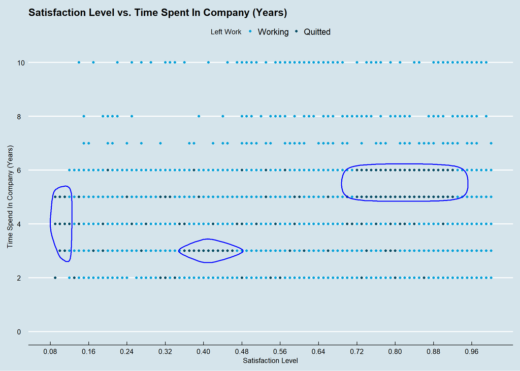

```r
gg <- ggplot(d,aes(satisfaction_level,time_spend_company))

gg <- gg + geom_point(aes(col=factor(d$left))) +  theme_economist() + scale_color_economist()

gg + geom_encircle(data=subset(d,
                               satisfaction_level>=0.72 &
                                 satisfaction_level<=0.92 &
                                 time_spend_company>4 &
                                 time_spend_company<6.02), colour="blue", expand=0.02,spread=0.02,size=2)+
  geom_encircle(data=subset(d,
                               satisfaction_level>=0.36 &
                                 satisfaction_level<=0.47 &
                                 time_spend_company==3 ), colour="blue", expand=0.02,spread=0.02,size=2)+
  geom_encircle(data=subset(d,
                               satisfaction_level>=0.08 &
                                 satisfaction_level<=0.12 &
                                 time_spend_company>=3 &
                                time_spend_company<=5), colour="blue", expand=0.02,spread=0.02,size=2)+

  scale_x_continuous(breaks=seq(0.08, 1, 0.08), limits = c(0.08, 1)) +
  scale_y_continuous(breaks =  seq(0,10,by=2), limits = c(0,10))+
  labs(x="Satisfaction Level",y="Time Spend In Company (Years)", title="Satisfaction Level vs. Time Spent In Company (Years)",col="Left Work")
```

In this new plot wee found the traces of previous groups above. The ones who left localized in the same *satisfaction level* ranges. So, we could attribute *time spent* to define the three groups above. For example, it is seen that the motivated last group leaves the company between four and six years. Their high motivation let them to keep the job for longer periods. May be they did not get the promotion or salary increase they expected through out the years and they leave at the end. Similarly, When we evaluated the other two groups in the last two graphs together, new characteristics of the groups become:

- *Group 1:* Low satisfaction level, long working hours and leaves in medium term (3-5 years)
- *Group 2:* Mediocre satisfaction level, low working hours and leaves early (around 3 years)
- *Group 3:* High satisfaction level and high working hours and leaves late (5-6 years)

Interestinly, people who passes years thereshold, does not tend to leave the company later. This must be because of the people’s reluctancy to go out of their comfort zone. Altough their salary and satisfaction level is low or at most mediocre, they still want to swim in the sea they know best.

To understand factors which cause resignation decision better, we also plotted the correlation matrix for the numerical variables.

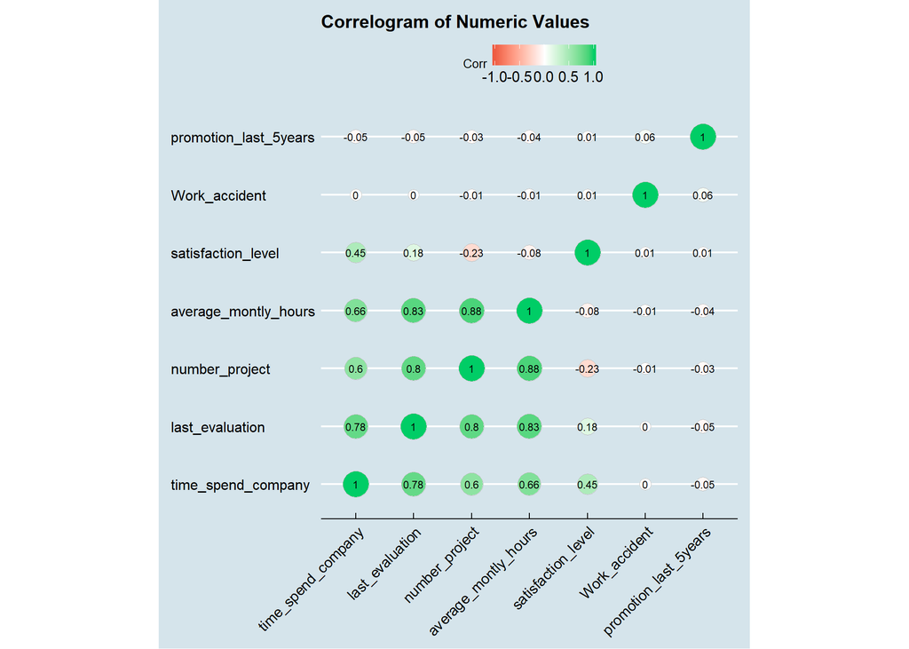

```r
CorrMat <- round(cor(dLeft[,0:7]),3)
ggcorrplot(CorrMat, hc.order = TRUE,
           #type = "lower",
           lab = TRUE,
           lab_size = 3,
           method="circle",
           colors = c("tomato2", "white", "springgreen3"),
           title="Correlogram of Numeric Values",
           ggtheme=theme_economist)
```

Correlogram created from numerical values in our dataset shows that Average Monthly Hours is highly correlated with Number Of Projects as expected. The ones who works on more than avarage (3) projects, should spend more time in the company. And also last evaluation score correlates highly with number of projects and average monthly hours. High evaluation score is given to people who works on more projects by spending more time in the company.

## Principal Component Analysis

With the insight gained from the correlation matrix of the employees who are already left. Before starting to principal component analysis we need to transform salaries to numeric values to see their effect on left rate. We need also to scale our data to avoid the dominance of the columns with high variance.

[output not shown]

```r
names(dLeft)
```

```
## [1] "satisfaction_level"    "last_evaluation"       "number_project"
## [4] "average_montly_hours"  "time_spend_company"    "Work_accident"
## [7] "promotion_last_5years" "departments"           "salary"
```

```r
dLeft_pca <- dLeft  %>% mutate(salary_Num = ifelse(salary == "low", 0, ifelse(salary == "medium", 1, 2))) %>% select(-salary,-departments)
pca_w_scaling<-princomp(as.matrix(dLeft_pca[,1:8]),cor=TRUE)
summary(pca_w_scaling,loadings=TRUE)
```

```
## Importance of components:
##                           Comp.1    Comp.2    Comp.3    Comp.4    Comp.5
## Standard deviation     1.8162209 1.1428322 1.0272619 1.0030200 0.9672535
## Proportion of Variance 0.4123323 0.1632582 0.1319084 0.1257561 0.1169474
## Cumulative Proportion  0.4123323 0.5755905 0.7074989 0.8332550 0.9502024
##                            Comp.6     Comp.7     Comp.8
## Standard deviation     0.41439073 0.36124911 0.31009692
## Proportion of Variance 0.02146496 0.01631261 0.01202001
## Cumulative Proportion  0.97166737 0.98797999 1.00000000
##
## Loadings:
##                       Comp.1 Comp.2 Comp.3 Comp.4 Comp.5 Comp.6 Comp.7
## satisfaction_level            0.852                       0.352 -0.147
## last_evaluation       -0.522                              0.433  0.584
## number_project        -0.493 -0.317                              0.199
## average_montly_hours  -0.510 -0.194                       0.253 -0.773
## time_spend_company    -0.468  0.359                      -0.790
## Work_accident                        0.686  0.326 -0.649
## promotion_last_5years                0.712 -0.129  0.689
## salary_Num                          -0.140  0.936  0.320
##                       Comp.8
## satisfaction_level     0.350
## last_evaluation       -0.442
## number_project         0.784
## average_montly_hours  -0.199
## time_spend_company    -0.166
## Work_accident
## promotion_last_5years
## salary_Num
```

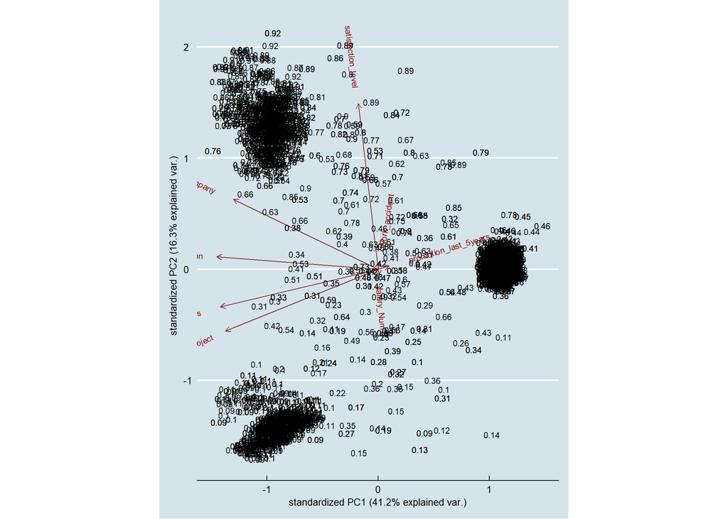

```r
ggbiplot(pca_w_scaling, labels= dLeft$satisfaction_level) +theme_economist()+ scale_color_economist()
```

The first four components explains %83 of the variance. With five components even 95% of the variance can be explained. Components that explain lower than 10% of the variance are not considered because they do not contribute much. When we look at the loadings, we understan that PC1 is composed of last evaluation, number of projects, monthly hours and time spent columns; PC2 is composed of satisfaction level, number of projects, monthly hours and time spent columns; PC3 and PC4 are composed of accident, salary and promotion columns. PCA is usefull for dimensionality reduction and we are glad to know that HR data can be explained in number of components lesser than total number of columns.

Principal components (eigenvectors) are linear combinations of actual factors (loadings) with constant coefficients (eigenvalues). By definition they are orthogonal (perpendicular) to eachother. First two eigenvectors maximizes the variance most (explains better). So, when we plot each factor scores in PC1-PC2 plane, we highlighted groups of homogenous individiuals. In the biplot above each point is labelled with satisfaction score, so we can conclude that people left are groupped according to their satisfaction value: very low, medium, high. We believe that groups deduced from PCA matches groups identified from the scatter plots previously.

Also cumulative variance plot is show below:

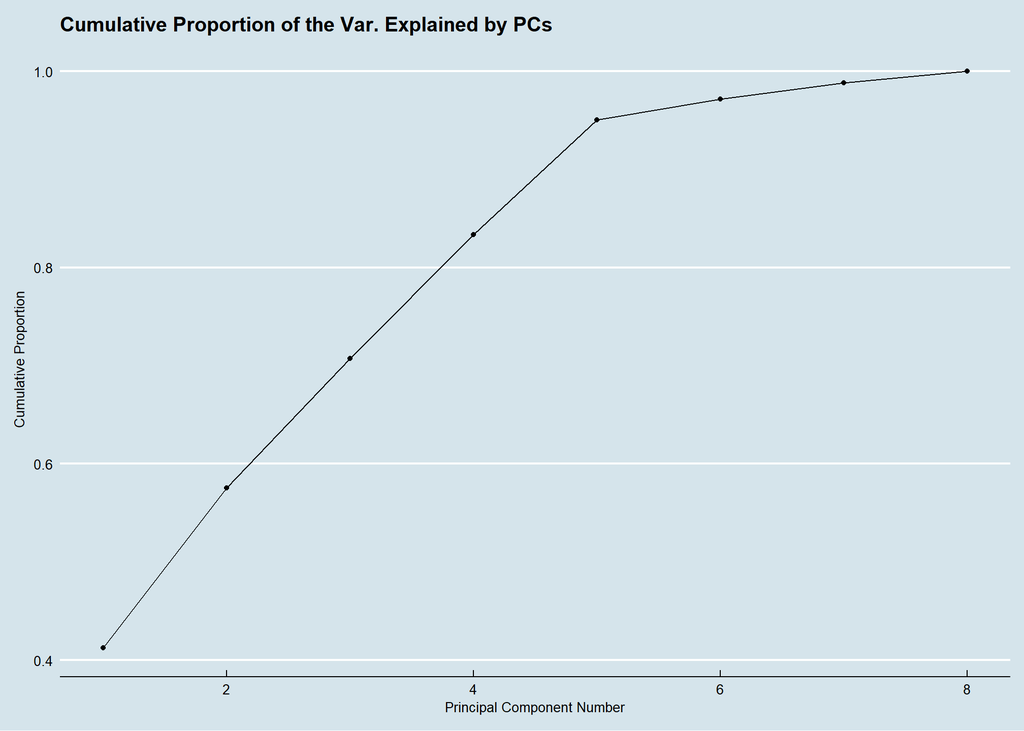

```r
ggplot(data.frame(pc=1:8,cum_var=c(0.4123323, 0.5755905, 0.7074989, 0.8332550,0.9502024,0.97166737,0.98797999,1.00000000)),aes(x=pc,y=cum_var)) +
  theme_economist() +
  scale_color_economist() +
  geom_point() +
  geom_line() +
  labs(x="Principal Component Number",
       y="Cumulative Proportion",
       title="Cumulative Proportion of the Var. Explained by PCs")
```

## K-Means Clustering

We tried K-Means clustering to be able to cluster mass of people who left the company. We applied k-Means with 3 clusters and 30 iterations since we expect to find three groups.

```r
#Filter to get the data from left people only
dleft<- subset(d, left=='Quitted')
dleft<- select(dleft,-left)


#apply k-means with 3 clusters and 30 iterations
set.seed(42)
dleft_Cluster <- kmeans(dleft[, 1:7], 3, nstart = 30)

dleft_Cluster$centers
```

```
##   satisfaction_level last_evaluation number_project average_montly_hours
## 1          0.6100000       0.8891911       4.936889             243.6409
## 2          0.4159149       0.5306140       2.178723             144.8322
## 3          0.2511361       0.8628964       5.780275             285.0799
##   time_spend_company Work_accident promotion_last_5years
## 1           4.778667    0.05333333          0.0008888889
## 2           3.071733    0.04741641          0.0091185410
## 3           4.262172    0.03870162          0.0037453184
```

```r
#print(sum(dleft_Cluster$withinss))
```

When we compare the center values of three clusters with our previously defined groups our scatter plots (Satisfaction Level vs. Avg. Monthly Hours, Satisfaction Level vs. Time Spend In Company), we are able to match them.

Thus, one can conclude that leaving reasons depends on the employee’s characteristics. Ones with medium satisfaction level, do not dedicate to work very much may be because they do not see any future in the company and quit early. Self-motivated ones work patiently long hours for long years but at the end they quit. Even low satisfied ones could work for very long hours they quit in medium terms.

## Decision Tree Analysis and Prediction

We first set seed to a constant value.

```r
set.seed(42)
```

Then *left* column is chosen as response and the rest are chosen as predictors. We put them in a data frame.

```r
  d <- d %>% # read in the data
  select(left, departments, satisfaction_level,
         last_evaluation, number_project, average_montly_hours,
         time_spend_company, promotion_last_5years, salary) %>%
  mutate(departments = factor(departments),
         salary = factor(salary))
head(d)
```

```
## # A tibble: 6 x 9
##      left departments satisfaction_level last_evaluation number_project
##    <fctr>      <fctr>              <dbl>           <dbl>          <int>
## 1 Quitted       sales               0.38            0.53              2
## 2 Quitted       sales               0.80            0.86              5
## 3 Quitted       sales               0.11            0.88              7
## 4 Quitted       sales               0.72            0.87              5
## 5 Quitted       sales               0.37            0.52              2
## 6 Quitted       sales               0.41            0.50              2
## # ... with 4 more variables: average_montly_hours <int>,
## #   time_spend_company <int>, promotion_last_5years <int>, salary <fctr>
```

Split the data in train and test

```r
n <- nrow(d)
indices <- sample(n, n*0.7)
train_d <- d[indices, ]
test_d <- d[-indices, ]
head(train_d)
```

```
## # A tibble: 6 x 9
##      left departments satisfaction_level last_evaluation number_project
##    <fctr>      <fctr>              <dbl>           <dbl>          <int>
## 1 Working     support               0.47            0.43              4
## 2 Working  management               0.62            0.61              3
## 3 Working       sales               0.90            0.88              4
## 4 Quitted       RandD               0.37            0.54              2
## 5 Working   technical               0.80            0.70              3
## 6 Working       RandD               0.88            0.92              3
## # ... with 4 more variables: average_montly_hours <int>,
## #   time_spend_company <int>, promotion_last_5years <int>, salary <fctr>
```

We fit the model

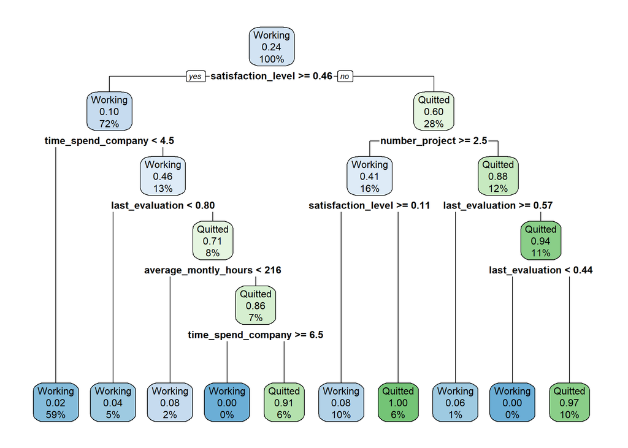

```r
rtree_fit <- rpart(left ~ ., data = train_d)
rpart.plot(rtree_fit)
```

To test the fit quality, we applied our model with fitted parameters to test data.

```r
res <- predict(rtree_fit, test_d)
auc(as.numeric(test_d$left) - 1, res[, 2])
```

```
## Area under the curve: 0.9768
```

Secondary factor that determines the satisfied employees quit decision is **time spent in the company**. If someone is working in the same company between 4.5 - 6.5 years, they break their comfort zone and flee because they work for long hours (> 216 h monthly basis) even if their bosses are very happy with their work (evaluation score > 0.80). We belive that this category corresponds to patient, hardworking, motivated employees of **Cluster 1** (i.e. Group 3).

## Conclusion

Our EDA is in good compliance with the results deduced from K-Means clustering. We are able to match our previously found groups with three clusters. With help of PCA we ensured that employees quitted falls into three subgroups with differing satisfaction scores. Furthermore Decision Tree Analysis supports our findings. As a conlusion, we find that the satisfaction level is the key factor to quit the job.

The company of interest is not paying much to its employees or promotes. Low and medium salary ranges are the highest portion of their pay check. Thus, since everbody is equal in the minimum, salary and promotion are not that important as satisfaction level. If employee’s satisfaction level is higher than 0.46, he/she will not quit in a short period. However, when the satisfaction level decreases, other factors will become important for the resignation decison such as number of projects or working hours.

This company has three different categories of employees left. First group is working very hard with low satisfaction level, it is expected that this group members quit the job. Second group has low(close to medium) satisfaction level and average monthly hours but they leave, for this group time spend company is the decision factor. People are leaving before 4,5 years from company. Most probably, they leave the company earlier if there is no uptunn in their working conditions.

## References

[Human Resources Analytics Data Set](https://www.kaggle.com/ludobenistant/hr-analytics/data)

[Explore & Explain: Density & Decision Trees](https://www.kaggle.com/msjgriffiths/explore-explain-density-decision-trees)

[Titanic: Getting Starting with R - Part 3: Decision Trees](http://trevorstephens.com/kaggle-titanic-tutorial/r-part-3-decision-trees/)

[Intro to Decision Trees with R Example](https://rpubs.com/osazuwa/123908)

[StackExchange](https://stats.stackexchange.com/questions/2038/interpretation-of-biplots-in-principal-components-analysis)